# Bacteria-plasmid interactions

## 2.1 Supplementary figure of plasmid clusters

```r
setwd("C:/Users/risel/Dropbox/Sommer postdoc/Plasmid project/PlasmidProjectAnalysis/Updated analysis2")
ps<-readRDS( "R_OUTPUT/plasmid_ps_clustered_04.03.22.RDS")

final_clusters<-taxa_names(ps)
head(n)
```

|  | x | y | name | degree | ClusterMembership | xend | yend | weight | Resistance |
| --- | --- | --- | --- | --- | --- | --- | --- | --- | --- |
| 2 | 0.006267429 | 0.5052244 | k141_1043921 | 1 | 150 | 0.00000000 | 0.5129306 | 5 | TRUE |
| 6 | 0.015915155 | 0.4571235 | k141_331385 | 2 | 12 | 0.01210346 | 0.4456294 | 5 | FALSE |
| 7 | 0.019329263 | 0.4702212 | k141_2405727 | 2 | 12 | 0.01591515 | 0.4571235 | 9 | FALSE |
| 8 | 0.019329263 | 0.4702212 | k141_2405727 | 2 | 12 | 0.02251722 | 0.4812966 | 7 | FALSE |
| 11 | 0.023456884 | 0.6262621 | k141_936990 | 1 | 160 | 0.01393029 | 0.6299269 | 6 | FALSE |
| 12 | 0.023984080 | 0.5711318 | k141_895815 | 1 | 318 | 0.01277004 | 0.5669136 | 5 | FALSE |

```r
length(unique(subset(n, ClusterMembership %in% final_clusters)$ClusterMembership))
```

```
## [1] 289
```

```r
length(unique(subset(n, ClusterMembership %in% final_clusters)$name))
```

```
## [1] 729
```

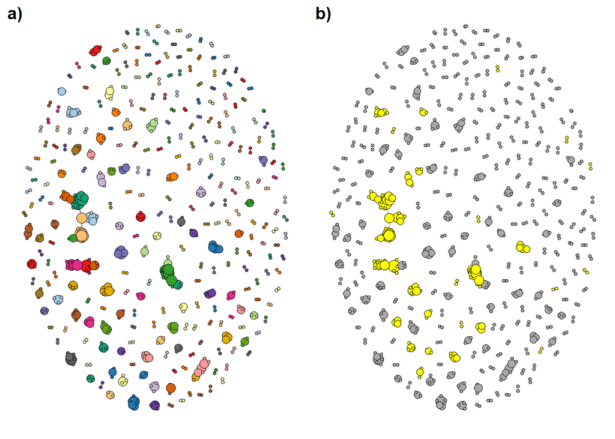

```r
p1<-ggplot(subset(n, ClusterMembership %in% final_clusters), aes(x = x, y = y, xend = xend, yend = yend, label = ClusterMembership)) +
  geom_edges( color = "black", alpha = 0.5) +
  theme_blank()+
  geom_nodes(aes(size = sqrt(degree), fill = ClusterMembership), pch = 21, alpha = 1)+
  scale_size(range = c(1,5))+
 # ggtitle("Putative plasmid clusters")+
  scale_fill_manual(values = mypal3)+
  theme(legend.position = "none")

  p2<-ggplot(subset(n, ClusterMembership %in% final_clusters), aes(x = x, y = y, xend = xend, yend = yend, label = name)) +
  geom_edges( color = "grey", alpha = 1) +
  theme_blank()+
  geom_nodes(aes(size =degree, fill = Resistance), pch = 21, alpha = 1)+
  scale_size(range = c(1, 5))+
  #ggtitle("Plasmid contig association network coloured by AMR")+
  scale_fill_manual(values = c("darkgrey", "yellow"))+
   theme(legend.position = "none")

  ggarrange(p1, p2, labels = c("a)", "b)"))
```

```r
#check k141_736244
```

### 2.1.1 Calculate plasmid length

```r
## add number of contigs that make up each cluster

contig_no<-data.frame(table(cluster_df$ClusterMembership))
cluster_df$ContigNo<-expss::vlookup(cluster_df$ClusterMembership, contig_no, lookup_column = "Var1", result_column = "Freq")

## add contig length
contig_length <- read.table("C:/Users/risel/Dropbox/Sommer postdoc/Plasmid project/PlasmidProjectAnalysis/Updated analysis2/DATA/contig_length.tsv", quote="\"", comment.char="")
head(contig_length)
```

|  | V1 | V2 |
| --- | --- | --- |
| 1 | k141_7 | 215 |
| 2 | k141_8 | 300 |
| 3 | k141_9 | 316 |
| 4 | k141_10 | 341 |
| 5 | k141_11 | 347 |
| 6 | k141_12 | 348 |

```r
summary(contig_length)
```

```
##       V1                  V2
##  Length:3627876     Min.   :   200
##  Class :character   1st Qu.:   366
##  Mode  :character   Median :   511
##                     Mean   :   893
##                     3rd Qu.:   848
##                     Max.   :312615
```

```r
cluster_df$LengthKB<- vlookup(cluster_df$name, contig_length, lookup_column = 1, result_column = 2)

table(is.na(cluster_df$LengthKB))
```

```
##
## FALSE
##   807
```

```r
plasmid_length<-cluster_df %>% group_by(ClusterMembership) %>% summarise(TotalLengthKB = sum(LengthKB))

summary(plasmid_length$TotalLengthKB)
```

```
##    Min. 1st Qu.  Median    Mean 3rd Qu.    Max.
##   466.0   812.8  1259.0  4187.6  2565.5 78669.0
```

### 2.1.2 Keep only MAG-PLASMID associations

- Ultimately, we are interested in Mag-plasmid connections
- So at this point, we filter down our HiC links df to include only links between MAG contigs and plasmid contigs
- We couldnt do this before, because we didn’t know which plasmid contigs to keep (based on clustering)

```r
# keep only links that involve MAGs, and make sure they are all in one column
# at the moment they are spread out across the left and right columns

head(WW_links_filt5)
```

| V1 | V2 | V3 | contig1_assignment | contig2_assignment |
| --- | --- | --- | --- | --- |
| k141_100327 | k141_1000981 | 1 | PLASMID | MAG |
| k141_1009898 | k141_1009200 | 1 | MAG | PLASMID |
| k141_1011540 | k141_100703 | 1 | PLASMID | MAG |
| k141_1011540 | k141_1011601 | 1 | PLASMID | MAG |
| k141_1012715 | k141_1011201 | 1 | PLASMID | MAG |
| k141_1013087 | k141_1004573 | 1 | MAG | PLASMID |

```r
mag1<- subset(WW_links_filt5, contig1_assignment=="MAG")
mag2<- subset(WW_links_filt5, contig2_assignment=="MAG")

head(mag1)
```

| V1 | V2 | V3 | contig1_assignment | contig2_assignment |
| --- | --- | --- | --- | --- |
| k141_1009898 | k141_1009200 | 1 | MAG | PLASMID |
| k141_1013087 | k141_1004573 | 1 | MAG | PLASMID |
| k141_1010681 | k141_1018622 | 1 | MAG | PLASMID |
| k141_1013408 | k141_1020447 | 1 | MAG | PLASMID |
| k141_1022757 | k141_1012797 | 3 | MAG | PLASMID |
| k141_1022757 | k141_1022808 | 2 | MAG | PLASMID |

```r
head(mag2)
```

| V1 | V2 | V3 | contig1_assignment | contig2_assignment |
| --- | --- | --- | --- | --- |
| k141_100327 | k141_1000981 | 1 | PLASMID | MAG |
| k141_1011540 | k141_100703 | 1 | PLASMID | MAG |
| k141_1011540 | k141_1011601 | 1 | PLASMID | MAG |
| k141_1012715 | k141_1011201 | 1 | PLASMID | MAG |
| k141_1008033 | k141_102722 | 1 | PLASMID | MAG |
| k141_1006808 | k141_1032230 | 1 | PLASMID | MAG |

```r
# change columns of mag2 around so they match mag1
mag2<-mag2[,c(2,1,3,5,4)]
names(mag2)<-names(mag1)

WW_links_filt6<-rbind(mag1, mag2)
head(WW_links_filt6)
```

| V1 | V2 | V3 | contig1_assignment | contig2_assignment |
| --- | --- | --- | --- | --- |
| k141_1009898 | k141_1009200 | 1 | MAG | PLASMID |
| k141_1013087 | k141_1004573 | 1 | MAG | PLASMID |
| k141_1010681 | k141_1018622 | 1 | MAG | PLASMID |
| k141_1013408 | k141_1020447 | 1 | MAG | PLASMID |
| k141_1022757 | k141_1012797 | 3 | MAG | PLASMID |
| k141_1022757 | k141_1022808 | 2 | MAG | PLASMID |

```r
# change column names
names(WW_links_filt6)[1:3]<-c("contigs_mags", "contigs_plasmids", "Count")

table(WW_links_filt6$contig2_assignment) # still AMR genes in there. Remove
```

```
##
##     AMR PLASMID
##    7805  147858
```

```r
WW_links_filt6<-subset(WW_links_filt6, contig2_assignment == "PLASMID")
head(WW_links_filt6)
```

| contigs_mags | contigs_plasmids | Count | contig1_assignment | contig2_assignment |
| --- | --- | --- | --- | --- |
| k141_1009898 | k141_1009200 | 1 | MAG | PLASMID |
| k141_1013087 | k141_1004573 | 1 | MAG | PLASMID |
| k141_1010681 | k141_1018622 | 1 | MAG | PLASMID |
| k141_1013408 | k141_1020447 | 1 | MAG | PLASMID |
| k141_1022757 | k141_1012797 | 3 | MAG | PLASMID |
| k141_1022757 | k141_1022808 | 2 | MAG | PLASMID |

```r
dim(WW_links_filt6)
```

```
## [1] 147858      5
```

```r
length(unique(WW_links_filt6$contigs_mags))
```

```
## [1] 34584
```

```r
length(unique(WW_links_filt6$contigs_plasmids))
```

```
## [1] 43636
```

- Only keep plasmid contigs that are clustered
- This information is stored in the object “cluster_df”

```r
head(cluster_df)
```

|  | name | ClusterMembership | Resistance | ContigNo | LengthKB |
| --- | --- | --- | --- | --- | --- |
| 122 | k141_3140497 | 1 | FALSE | 6 | 414 |
| 159 | k141_1718662 | 1 | TRUE | 6 | 519 |
| 1251 | k141_1847458 | 1 | FALSE | 6 | 882 |
| 4881 | k141_2333875 | 1 | FALSE | 6 | 892 |
| 6191 | k141_2279036 | 1 | TRUE | 6 | 301 |
| 7361 | k141_261801 | 1 | FALSE | 6 | 499 |

```r
WW_links_filt6$Cluster<- vlookup(WW_links_filt6$contigs_plasmids, cluster_df, lookup_column = "name", result_column = "ClusterMembership")

length(unique(WW_links_filt6$Cluster)) # how many clusters?
```

```
## [1] 316
```

```r
WW_links_filt6$Cluster<-factor(WW_links_filt6$Cluster)

# remove any plasmid inks that are not assigned a cluster

WW_links_filt7<-na.omit(WW_links_filt6)

head(WW_links_filt7)
```

| contigs_mags | contigs_plasmids | Count | contig1_assignment | contig2_assignment | Cluster |
| --- | --- | --- | --- | --- | --- |
| k141_1025044 | k141_1037797 | 1 | MAG | PLASMID | 21 |
| k141_1001088 | k141_1043795 | 1 | MAG | PLASMID | 4 |
| k141_1001609 | k141_1043795 | 1 | MAG | PLASMID | 4 |
| k141_1004098 | k141_1043795 | 2 | MAG | PLASMID | 4 |
| k141_1006126 | k141_1043795 | 2 | MAG | PLASMID | 4 |
| k141_1007900 | k141_1043795 | 1 | MAG | PLASMID | 4 |

```r
dim(WW_links_filt7)
```

```
## [1] 15328     6
```